# Kelompok 6 ADW

M. Akbar, M. Fahrul, Kanaya, Dede

2023-12-14

# Tugas Kelompok 6 ADW

## Anggota Kelompok :

- **M. Akbar Resdika_121450066**
- **Kanaya Dea Thalita Akhmad_121450001**
- **Dede Masita_121450007**
- **Mohammad Fahrul Aditya_121450166**

### Import Packages

```r
library(readxl)
library(tseries)
library(forecast)
```

```r
library(ggplot2)
library(seasonal)
library(fUnitRoots)
library(urca)
library(TSA)
library(fGarch)
library(vars)
library(dplyr)
library(FinTS)
library(rugarch)
```

### Import Data

```r
kurs <- read_excel("E:/Kurs Transaksi USD-IDR (1).xlsx")
```

### Data Teratas

```r
head(kurs)
```

```
## # A tibble: 6 x 2
##   Tanggal               `Kurs Jual`
##   <chr>                       <dbl>
## 1 8/31/2023 12:00:00 AM      15315.
## 2 8/30/2023 12:00:00 AM      15339.
## 3 8/29/2023 12:00:00 AM      15370.
## 4 8/28/2023 12:00:00 AM      15373.
## 5 8/25/2023 12:00:00 AM      15329.
## 6 8/24/2023 12:00:00 AM      15396.
```

### Mengidentifikasi data time series

```r
kurs$Tanggal <- as.Date(kurs$Tanggal, format = "%m/%d/%Y %I:%M:%S %p")
kurs
```

```
## # A tibble: 658 x 2
##    Tanggal    `Kurs Jual`
##    <date>           <dbl>
##  1 2023-08-31      15315.
##  2 2023-08-30      15339.
##  3 2023-08-29      15370.
##  4 2023-08-28      15373.
##  5 2023-08-25      15329.
##  6 2023-08-24      15396.
##  7 2023-08-23      15403.
##  8 2023-08-22      15406.
##  9 2023-08-21      15385.
## 10 2023-08-18      15385.
## # ... with 648 more rows
```

```r
# Mengurutkan data berdasarkan kolom 'Tanggal' secara Ascending
kurs <- arrange(kurs,Tanggal)

# Menampilkan hasil
print(kurs)
```

```
## # A tibble: 658 x 2
##    Tanggal    `Kurs Jual`
##    <date>           <dbl>
##  1 2021-01-04      13973.
##  2 2021-01-05      14015.
##  3 2021-01-06      13996.
##  4 2021-01-07      14008.
##  5 2021-01-08      14128.
##  6 2021-01-11      14226.
##  7 2021-01-12      14302.
##  8 2021-01-13      14180.
##  9 2021-01-14      14190.
## 10 2021-01-15      14138.
## # ... with 648 more rows
```

```r
str(kurs)
```

```
## tibble [658 x 2] (S3: tbl_df/tbl/data.frame)
##  $ Tanggal  : Date[1:658], format: "2021-01-04" "2021-01-05" ...
##  $ Kurs Jual: num [1:658] 13973 14015 13996 14008 14128 ...
```

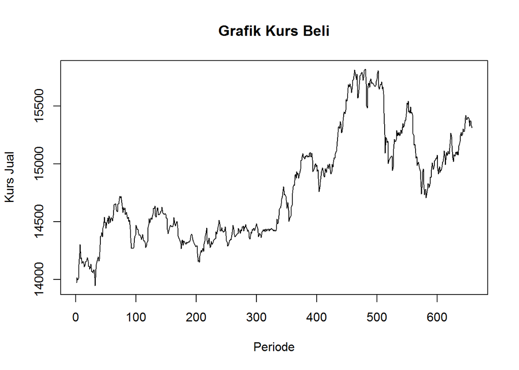

```r
# Membuat objek deret waktu
kurs_ts <- ts(kurs$`Kurs Jual`, start = start(kurs$Tanggal), frequency = 1)

# Plot deret waktu
ts.plot(kurs_ts, xlab = "Periode", ylab = "Kurs Jual", main = "Grafik Kurs Beli")
```

### Melakukan uji stasioneritas data menggunakan Augmented Dickey-Fuller Test (ADF)

```r
adf.test(kurs_ts)
```

```
##
##  Augmented Dickey-Fuller Test
##
## data:  kurs_ts
## Dickey-Fuller = -2.4327, Lag order = 8, p-value = 0.3952
## alternative hypothesis: stationary
```

### Melakukan differencing & transformasi

dilakukan differencing untuk menstasionerkan terhadap rataan

```r
diff_kurs_ts <- diff(log(kurs_ts))
```

### Mengidentifikasi data kembali setelah dilakukan differencing & transformasi

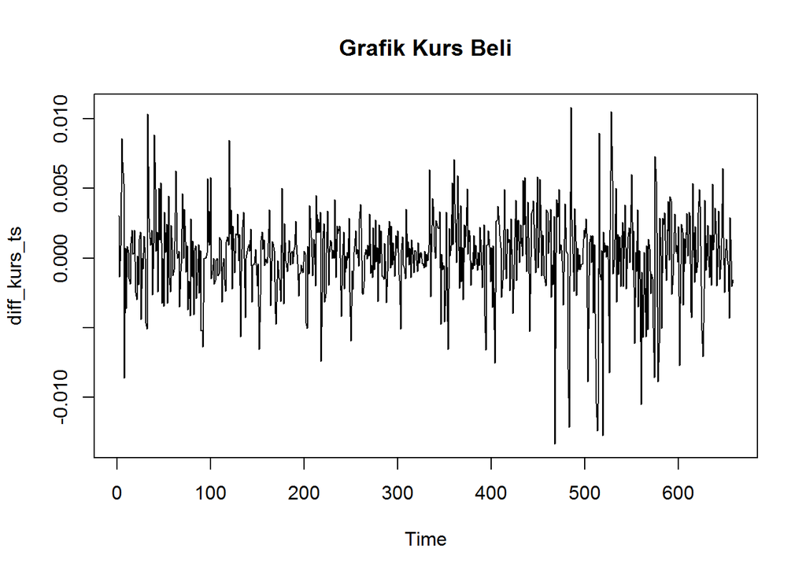

```r
ts.plot(diff_kurs_ts, main = "Grafik Kurs Beli")
```

### Mengidentifikasi komponen ARIMA menggunakan model ACF & PACF Setelah di differencing & transform)))

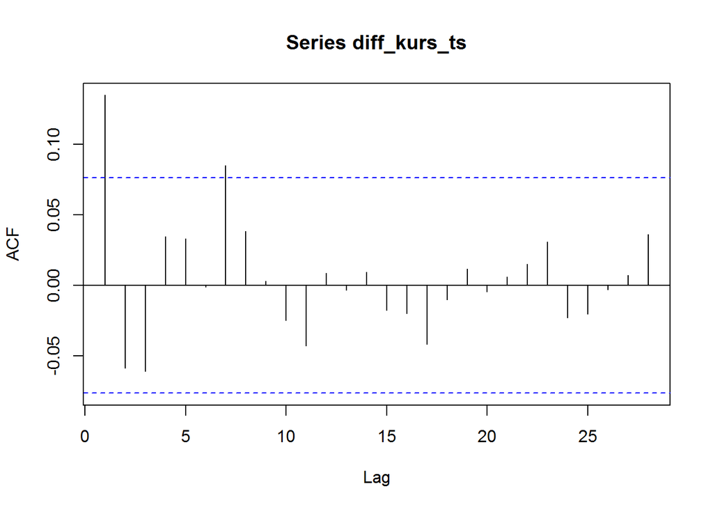

```r
acf(diff_kurs_ts)
```

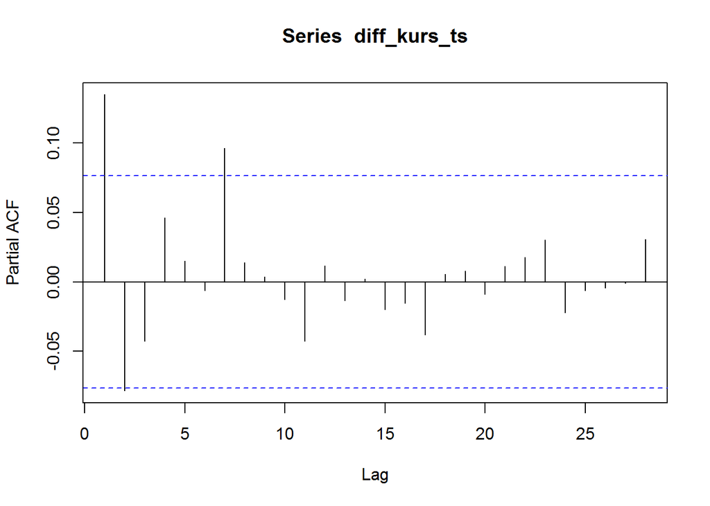

```r
pacf(diff_kurs_ts)
```

### Melakukan uji stasioneritas data menggunakan Augmented Dickey-Fuller Test (ADF) setelah di differencing

```r
adf.test(diff_kurs_ts)
```

```
##
##  Augmented Dickey-Fuller Test
##
## data:  diff_kurs_ts
## Dickey-Fuller = -7.5388, Lag order = 8, p-value = 0.01
## alternative hypothesis: stationary
```

Dapat dilihat bahwa nilai p-value < 0,05 yang mengartikan bahwa data sudah stasioner

### Estimasi Parameter

```r
eacf(diff_kurs_ts)
```

```
## AR/MA
##   0 1 2 3 4 5 6 7 8 9 10 11 12 13
## 0 x o o o o o x o o o o  o  o  o
## 1 x x o o o o o o o o o  o  o  o
## 2 x x o o o o x o o o o  o  o  o
## 3 x x x o o o x o o o o  o  o  o
## 4 x x o o o o o o o o o  o  o  o
## 5 x o x x x o o o o o o  o  o  o
## 6 o x x x x x x o o o o  o  o  o
## 7 x o x x x x o x o o o  o  o  o
```

Berdasarkan plot diatas didapatkan bahwa kandidiat model ARIMA sebagai berikut :

ARIMA(3,1,3)

ARIMA(0,1,1)

ARIMA(1,1,4)

ARIMA(1,1,3)

#### Model ARIMA

```r
model1 <- Arima(diff_kurs_ts,order = c(3,1,3),method ="ML")
summary(model1)
```

```
## Series: diff_kurs_ts
## ARIMA(3,1,3)
##
## Coefficients:
##           ar1      ar2      ar3      ma1      ma2      ma3
##       -0.4518  -0.4810  -0.0146  -0.4011  -0.0908  -0.5081
## s.e.   0.3943   0.2116   0.0596   0.3930   0.3264   0.2471
##
## sigma^2 = 9.223e-06:  log likelihood = 2871.77
## AIC=-5729.55   AICc=-5729.37   BIC=-5698.14
##
## Training set error measures:
##                        ME        RMSE        MAE MPE MAPE     MASE         ACF1
## Training set -0.000106111 0.003020711 0.00216986 NaN  Inf 0.718356 -0.001051038
```

```r
model2 <- Arima(diff_kurs_ts,order = c(0,1,1),method ="ML")
summary(model2)
```

```
## Series: diff_kurs_ts
## ARIMA(0,1,1)
##
## Coefficients:
##           ma1
##       -1.0000
## s.e.   0.0052
##
## sigma^2 = 9.435e-06:  log likelihood = 2861.75
## AIC=-5719.5   AICc=-5719.49   BIC=-5710.53
##
## Training set error measures:
##                         ME        RMSE         MAE  MPE MAPE      MASE
## Training set -0.0001114252 0.003066981 0.002189661 -Inf  Inf 0.7249115
##                   ACF1
## Training set 0.1357399
```

```r
model3 <- Arima(diff_kurs_ts,order = c(1,1,4),method ="ML")
summary(model3)
```

```
## Series: diff_kurs_ts
## ARIMA(1,1,4)
##
## Coefficients:
##           ar1      ma1      ma2      ma3     ma4
##       -0.3018  -0.5523  -0.4426  -0.0835  0.0784
## s.e.   0.2827   0.2800   0.2396   0.0595  0.0403
##
## sigma^2 = 9.237e-06:  log likelihood = 2870.74
## AIC=-5729.47   AICc=-5729.34   BIC=-5702.55
##
## Training set error measures:
##                         ME        RMSE         MAE MPE MAPE      MASE
## Training set -0.0001087819 0.003025404 0.002176482 NaN  Inf 0.7205483
##                      ACF1
## Training set -0.001593312
```

```r
model4 <- Arima(diff_kurs_ts,order = c(1,1,3),method ="ML")
summary(model4)
```

```
## Series: diff_kurs_ts
## ARIMA(1,1,3)
##
## Coefficients:
##          ar1      ma1     ma2    ma3
##       0.3366  -1.1940  0.0959  0.098
## s.e.  0.3329   0.3306  0.2900  0.057
##
## sigma^2 = 9.256e-06:  log likelihood = 2869.61
## AIC=-5729.21   AICc=-5729.12   BIC=-5706.78
##
## Training set error measures:
##                         ME      RMSE         MAE MPE MAPE      MASE
## Training set -0.0001065143 0.0030307 0.002188852 NaN  Inf 0.7246437
##                      ACF1
## Training set 0.0007772901
```

```r
Model <- c("ARIMA (3,1,3)","ARIMA (0,1,1)","ARIMA (1,1,4)", "ARIMA (1,1,3)")
AIC <- c(model1$aic,model2$aic,model3$aic,model4$aic)
BIC <- c(model1$bic,model2$bic,model3$bic, model4$bic)
Akurasi <- data.frame(Model,AIC,BIC)
kableExtra::kable(Akurasi)
```

| Model | AIC | BIC |
| --- | --- | --- |
| ARIMA (3,1,3) | -5729.547 | -5698.144 |
| ARIMA (0,1,1) | -5719.504 | -5710.532 |
| ARIMA (1,1,4) | -5729.472 | -5702.555 |
| ARIMA (1,1,3) | -5729.210 | -5706.780 |

```r
paste("Model yang terbaik berdasarkan akurasi adalah model",Akurasi$Model[which.min(Akurasi[,"AIC"])])
```

```
## [1] "Model yang terbaik berdasarkan akurasi adalah model ARIMA (3,1,3)"
```

### Uji Diagnostik

#### Model ARIMA

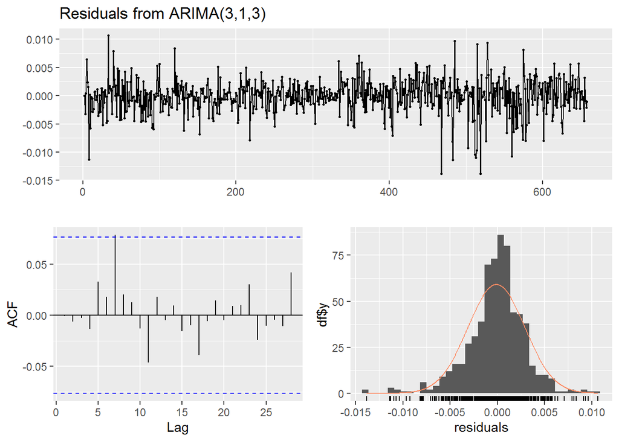

```
##
##  Ljung-Box test
##
## data:  Residuals from ARIMA(3,1,3)
## Q* = 5.6703, df = 4, p-value = 0.2252
##
## Model df: 6.   Total lags used: 10
```

```r
checkresiduals(model1)
```

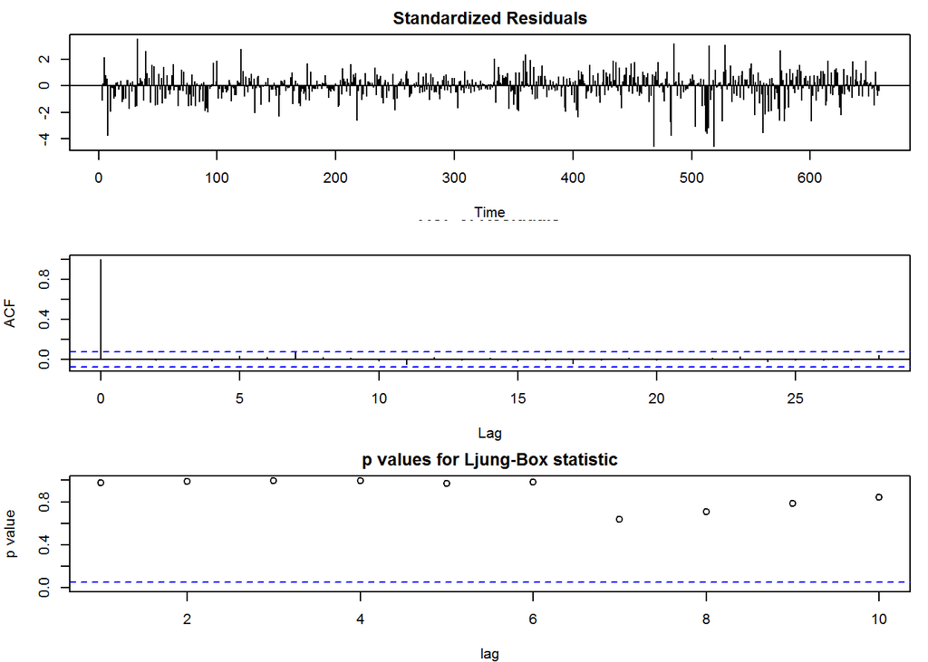

```r
par(mar = c(4, 4, 2, 1))
residual_model <- model1$residuals
tsdiag(model1)
```

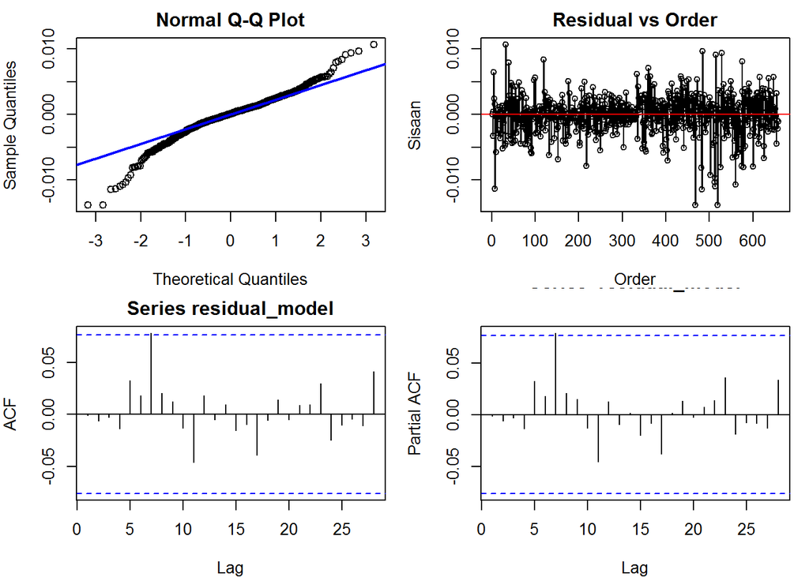

```r
par(mar = c(4, 4, 2, 1))
par(mfrow = c(2,2))
qqnorm(residual_model)
qqline(residual_model, col = "blue", lwd = 2)
plot(residual_model, type="o",
     ylab = "Sisaan", xlab = "Order", main = "Residual vs Order")
abline(h = 0, col='red')
acf(residual_model)
pacf(residual_model)
```

**Analisis**

- dapat dilihat pada grafik normal Q-Q Plot berdasarkan hasil plot diatas bahwa banyak amatan yang cenderung menjauhi garis lurus plot distribusi normal, sehingga dapat disimpulkan bahwa residual model belum cukup menyebar normal
- Dapat dilihat pada grafik residual vs order bahwa mayoritas plot residual bergerak di sekitar nol, tetapi terdapat beberapa amatan yang terletak jauh dari titik nol sehingga, belum dapat disimpulkan apakah terdapat autokorelasi atau tidak
- Pada plot lag pacf dan acf terdapat garis di lag tertentu yang melebihi tinggi garis biru, sehingga dapat dikatakan bahwa terdapat autokorelasi pada residual model

#### a) residual model menyebar normal

- H0 : residual mengikuti sebaran normal
- H1 : residual tidak mengikuti sebaran normal

```r
jarque.bera.test(residual_model)
```

```
##
##  Jarque Bera Test
##
## data:  residual_model
## X-squared = 224.48, df = 2, p-value < 2.2e-16
```

dapat dilihat bahwa nilai p-value < $\alpha$(0.05), sehingga tolak H0, artinya cukup bukti untuk menyatakan bahwa residual tidak menyebar normal pada taraf signifikasi $\alpha$(0.05)

#### B) residual model bebas/tidak ada autokorelasi

- H0 : Tidak ada autokorelasi
- H1 : Ada autokorelasi

```r
Box.test(residual_model, type = "Ljung")
```

```
##
##  Box-Ljung test
##
## data:  residual_model
## X-squared = 0.00072909, df = 1, p-value = 0.9785
```

dapat dilihat bahwa nilai p-value > $\alpha$(0.05), sehingga terima H0, artinya ada bukti untuk menyatakan bahwa tidak ada korelasi pada data pada taraf signifikasi $\alpha$(0.05)

### **Identifikasi Efek ARCH**

Identifikasi adanya proses ARCH pada sisaan model ARIMA(3,1,3) dapat dilakukan dengan uji *Lagrange Multiplier* (LM). Hipotesis yang digunakan adalah sebagai berikut:

H0 : Tidak terjadi heteroskedastisitas

H1 : Terjadi Heteroskedastisitas

```r
for (i in 1:15) {
  ArchTest <- ArchTest(residual_model, lags=i, demean=TRUE)
  cat("P Value LM Test lag ke", i,"adalah" , ArchTest$p.value, "\n") }
```

```
## P Value LM Test lag ke 1 adalah 0.0006269648
## P Value LM Test lag ke 2 adalah 4.42307e-05
## P Value LM Test lag ke 3 adalah 0.0001575386
## P Value LM Test lag ke 4 adalah 0.0003027556
## P Value LM Test lag ke 5 adalah 0.0005492427
## P Value LM Test lag ke 6 adalah 0.001156202
## P Value LM Test lag ke 7 adalah 1.010337e-05
## P Value LM Test lag ke 8 adalah 8.008951e-06
## P Value LM Test lag ke 9 adalah 2.61264e-05
## P Value LM Test lag ke 10 adalah 4.240543e-05
## P Value LM Test lag ke 11 adalah 5.952651e-05
## P Value LM Test lag ke 12 adalah 0.0001145746
## P Value LM Test lag ke 13 adalah 0.0001828623
## P Value LM Test lag ke 14 adalah 6.673714e-05
## P Value LM Test lag ke 15 adalah 5.352506e-06
```

hasil uji diperoleh nilai P−Value sampai lag ke-15 yang didapat lebih kecil dari α = 5%, maka keputusan yang diambil adalah Tolak H0. Dengan kata lain, dapat disimpulkan bahwa terdapat unsur heteroskedastisitas pada sisaan model ARIMA(3,1,3). Kondisi yang menolak H0 ini terjadi sampai dengan lag ke-15 sehingga dapat dikatakan bahwa indikasi pemodelan sisaan ini lebih cocok menggunakan model GARCH dibandingkan model ARCH.

### **Pemodelan GARCH**

```r
#alpha1 unsur ARCH 1 nya di lag residual kuadrat
#LM Archtestnya p value siginifikan, yg mau kita tuju adalah tidak signfikan, terdapat efek masih
garch10<-garchFit(~arma(3,3)+garch(1,0),data = diff_kurs_ts, trace = F)
a <- summary(garch10)
```

```
##
## Title:
##  GARCH Modelling
##
## Call:
##  garchFit(formula = ~arma(3, 3) + garch(1, 0), data = diff_kurs_ts,
##     trace = F)
##
## Mean and Variance Equation:
##  data ~ arma(3, 3) + garch(1, 0)
## <environment: 0x000000c87dfc62d0>
##  [data = diff_kurs_ts]
##
## Conditional Distribution:
##  norm
##
## Coefficient(s):
##          mu          ar1          ar2          ar3          ma1          ma2
##  5.2817e-05   6.5538e-01  -5.3912e-01   5.1895e-01  -5.6391e-01   4.1922e-01
##         ma3        omega       alpha1
## -4.5999e-01   7.3242e-06   1.9895e-01
##
## Std. Errors:
##  based on Hessian
##
## Error Analysis:
##          Estimate  Std. Error  t value Pr(>|t|)
## mu      5.282e-05   6.711e-05    0.787 0.431248
## ar1     6.554e-01   3.072e-01    2.134 0.032865 *
## ar2    -5.391e-01   1.982e-01   -2.720 0.006536 **
## ar3     5.189e-01   2.049e-01    2.533 0.011319 *
## ma1    -5.639e-01   3.082e-01   -1.830 0.067251 .
## ma2     4.192e-01   2.087e-01    2.009 0.044563 *
## ma3    -4.600e-01   2.145e-01   -2.144 0.032006 *
## omega   7.324e-06   5.225e-07   14.017  < 2e-16 ***
## alpha1  1.989e-01   5.896e-02    3.374 0.000741 ***
## ---
## Signif. codes:  0 '***' 0.001 '**' 0.01 '*' 0.05 '.' 0.1 ' ' 1
##
## Log Likelihood:
##  2895.134    normalized:  4.406596
##
## Description:
##  Thu Dec 14 15:14:06 2023 by user: PC
##
##
## Standardised Residuals Tests:
##                                  Statistic      p-Value
##  Jarque-Bera Test   R    Chi^2  191.376498 0.000000e+00
##  Shapiro-Wilk Test  R    W        0.967135 5.712567e-11
##  Ljung-Box Test     R    Q(10)    8.706229 5.601919e-01
##  Ljung-Box Test     R    Q(15)   10.220744 8.056295e-01
##  Ljung-Box Test     R    Q(20)   11.697875 9.260824e-01
##  Ljung-Box Test     R^2  Q(10)   30.522738 7.031967e-04
##  Ljung-Box Test     R^2  Q(15)   39.119269 6.150760e-04
##  Ljung-Box Test     R^2  Q(20)   49.612753 2.515679e-04
##  LM Arch Test       R    TR^2    28.564252 4.570765e-03
##
## Information Criterion Statistics:
##       AIC       BIC       SIC      HQIC
## -8.785796 -8.724320 -8.786164 -8.761963
```

```r
a
```

```
##
## Title:
##  GARCH Modelling
##
## Call:
##  garchFit(formula = ~arma(3, 3) + garch(1, 0), data = diff_kurs_ts,
##     trace = F)
##
## Mean and Variance Equation:
##  data ~ arma(3, 3) + garch(1, 0)
## <environment: 0x000000c87dfc62d0>
##  [data = diff_kurs_ts]
##
## Conditional Distribution:
##  norm
##
## Coefficient(s):
##          mu          ar1          ar2          ar3          ma1          ma2
##  5.2817e-05   6.5538e-01  -5.3912e-01   5.1895e-01  -5.6391e-01   4.1922e-01
##         ma3        omega       alpha1
## -4.5999e-01   7.3242e-06   1.9895e-01
##
## Std. Errors:
##  based on Hessian
##
## Error Analysis:
##          Estimate  Std. Error  t value Pr(>|t|)
## mu      5.282e-05   6.711e-05    0.787 0.431248
## ar1     6.554e-01   3.072e-01    2.134 0.032865 *
## ar2    -5.391e-01   1.982e-01   -2.720 0.006536 **
## ar3     5.189e-01   2.049e-01    2.533 0.011319 *
## ma1    -5.639e-01   3.082e-01   -1.830 0.067251 .
## ma2     4.192e-01   2.087e-01    2.009 0.044563 *
## ma3    -4.600e-01   2.145e-01   -2.144 0.032006 *
## omega   7.324e-06   5.225e-07   14.017  < 2e-16 ***
## alpha1  1.989e-01   5.896e-02    3.374 0.000741 ***
## ---
## Signif. codes:  0 '***' 0.001 '**' 0.01 '*' 0.05 '.' 0.1 ' ' 1
##
## Log Likelihood:
##  2895.134    normalized:  4.406596
##
## Description:
##  Thu Dec 14 15:14:06 2023 by user: PC
##
##
## Standardised Residuals Tests:
##                                  Statistic      p-Value
##  Jarque-Bera Test   R    Chi^2  191.376498 0.000000e+00
##  Shapiro-Wilk Test  R    W        0.967135 5.712567e-11
##  Ljung-Box Test     R    Q(10)    8.706229 5.601919e-01
##  Ljung-Box Test     R    Q(15)   10.220744 8.056295e-01
##  Ljung-Box Test     R    Q(20)   11.697875 9.260824e-01
##  Ljung-Box Test     R^2  Q(10)   30.522738 7.031967e-04
##  Ljung-Box Test     R^2  Q(15)   39.119269 6.150760e-04
##  Ljung-Box Test     R^2  Q(20)   49.612753 2.515679e-04
##  LM Arch Test       R    TR^2    28.564252 4.570765e-03
##
## Information Criterion Statistics:
##       AIC       BIC       SIC      HQIC
## -8.785796 -8.724320 -8.786164 -8.761963
```

```r
#beta 1 garch atau lag variansnya sendiri
garch11<-garchFit(~arma(3,3)+garch(1,1),data = diff_kurs_ts, trace = F)
b <- summary(garch11)
```

```
##
## Title:
##  GARCH Modelling
##
## Call:
##  garchFit(formula = ~arma(3, 3) + garch(1, 1), data = diff_kurs_ts,
##     trace = F)
##
## Mean and Variance Equation:
##  data ~ arma(3, 3) + garch(1, 1)
## <environment: 0x000000c87cd1f7b8>
##  [data = diff_kurs_ts]
##
## Conditional Distribution:
##  norm
##
## Coefficient(s):
##          mu          ar1          ar2          ar3          ma1          ma2
##  4.0874e-06   2.7619e-01   1.9817e-01   4.8889e-01  -1.5409e-01  -2.8632e-01
##         ma3        omega       alpha1        beta1
## -5.9923e-01   7.8033e-08   3.3271e-02   9.5647e-01
##
## Std. Errors:
##  based on Hessian
##
## Error Analysis:
##          Estimate  Std. Error   t value Pr(>|t|)
## mu      4.087e-06   8.597e-08    47.545  < 2e-16 ***
## ar1     2.762e-01   1.183e-04  2335.432  < 2e-16 ***
## ar2     1.982e-01   8.204e-05  2415.614  < 2e-16 ***
## ar3     4.889e-01   1.011e-04  4833.318  < 2e-16 ***
## ma1    -1.541e-01   2.988e-04  -515.667  < 2e-16 ***
## ma2    -2.863e-01   4.978e-04  -575.184  < 2e-16 ***
## ma3    -5.992e-01   2.997e-04 -1999.658  < 2e-16 ***
## omega   7.803e-08   5.085e-08     1.535  0.12490
## alpha1  3.327e-02   1.102e-02     3.020  0.00253 **
## beta1   9.565e-01   1.479e-02    64.671  < 2e-16 ***
## ---
## Signif. codes:  0 '***' 0.001 '**' 0.01 '*' 0.05 '.' 0.1 ' ' 1
##
## Log Likelihood:
##  2918.477    normalized:  4.442126
##
## Description:
##  Thu Dec 14 15:14:21 2023 by user: PC
##
##
## Standardised Residuals Tests:
##                                  Statistic      p-Value
##  Jarque-Bera Test   R    Chi^2  70.0646714 5.551115e-16
##  Shapiro-Wilk Test  R    W       0.9790346 4.324266e-08
##  Ljung-Box Test     R    Q(10)   2.0798378 9.956908e-01
##  Ljung-Box Test     R    Q(15)   3.3539034 9.992032e-01
##  Ljung-Box Test     R    Q(20)   4.6472802 9.998439e-01
##  Ljung-Box Test     R^2  Q(10)  10.6973474 3.815784e-01
##  Ljung-Box Test     R^2  Q(15)  15.3967488 4.232341e-01
##  Ljung-Box Test     R^2  Q(20)  17.0540029 6.494643e-01
##  LM Arch Test       R    TR^2   10.8805130 5.391856e-01
##
## Information Criterion Statistics:
##       AIC       BIC       SIC      HQIC
## -8.853810 -8.785504 -8.854264 -8.827329
```

```r
b
```

```
##
## Title:
##  GARCH Modelling
##
## Call:
##  garchFit(formula = ~arma(3, 3) + garch(1, 1), data = diff_kurs_ts,
##     trace = F)
##
## Mean and Variance Equation:
##  data ~ arma(3, 3) + garch(1, 1)
## <environment: 0x000000c87cd1f7b8>
##  [data = diff_kurs_ts]
##
## Conditional Distribution:
##  norm
##
## Coefficient(s):
##          mu          ar1          ar2          ar3          ma1          ma2
##  4.0874e-06   2.7619e-01   1.9817e-01   4.8889e-01  -1.5409e-01  -2.8632e-01
##         ma3        omega       alpha1        beta1
## -5.9923e-01   7.8033e-08   3.3271e-02   9.5647e-01
##
## Std. Errors:
##  based on Hessian
##
## Error Analysis:
##          Estimate  Std. Error   t value Pr(>|t|)
## mu      4.087e-06   8.597e-08    47.545  < 2e-16 ***
## ar1     2.762e-01   1.183e-04  2335.432  < 2e-16 ***
## ar2     1.982e-01   8.204e-05  2415.614  < 2e-16 ***
## ar3     4.889e-01   1.011e-04  4833.318  < 2e-16 ***
## ma1    -1.541e-01   2.988e-04  -515.667  < 2e-16 ***
## ma2    -2.863e-01   4.978e-04  -575.184  < 2e-16 ***
## ma3    -5.992e-01   2.997e-04 -1999.658  < 2e-16 ***
## omega   7.803e-08   5.085e-08     1.535  0.12490
## alpha1  3.327e-02   1.102e-02     3.020  0.00253 **
## beta1   9.565e-01   1.479e-02    64.671  < 2e-16 ***
## ---
## Signif. codes:  0 '***' 0.001 '**' 0.01 '*' 0.05 '.' 0.1 ' ' 1
##
## Log Likelihood:
##  2918.477    normalized:  4.442126
##
## Description:
##  Thu Dec 14 15:14:21 2023 by user: PC
##
##
## Standardised Residuals Tests:
##                                  Statistic      p-Value
##  Jarque-Bera Test   R    Chi^2  70.0646714 5.551115e-16
##  Shapiro-Wilk Test  R    W       0.9790346 4.324266e-08
##  Ljung-Box Test     R    Q(10)   2.0798378 9.956908e-01
##  Ljung-Box Test     R    Q(15)   3.3539034 9.992032e-01
##  Ljung-Box Test     R    Q(20)   4.6472802 9.998439e-01
##  Ljung-Box Test     R^2  Q(10)  10.6973474 3.815784e-01
##  Ljung-Box Test     R^2  Q(15)  15.3967488 4.232341e-01
##  Ljung-Box Test     R^2  Q(20)  17.0540029 6.494643e-01
##  LM Arch Test       R    TR^2   10.8805130 5.391856e-01
##
## Information Criterion Statistics:
##       AIC       BIC       SIC      HQIC
## -8.853810 -8.785504 -8.854264 -8.827329
```

```r
garch37<-garchFit(~arma(3,3)+garch(3,7),data = diff_kurs_ts, trace = F)
c <- summary(garch37)
```

```
##
## Title:
##  GARCH Modelling
##
## Call:
##  garchFit(formula = ~arma(3, 3) + garch(3, 7), data = diff_kurs_ts,
##     trace = F)
##
## Mean and Variance Equation:
##  data ~ arma(3, 3) + garch(3, 7)
## <environment: 0x000000c87bd1ccd0>
##  [data = diff_kurs_ts]
##
## Conditional Distribution:
##  norm
##
## Coefficient(s):
##          mu          ar1          ar2          ar3          ma1          ma2
##  2.1598e-06   3.6738e-01   9.9139e-02   4.9996e-01  -2.8041e-01  -2.0787e-01
##         ma3        omega       alpha1       alpha2       alpha3        beta1
## -5.6458e-01   4.2417e-07   1.7003e-01   2.2029e-02   1.0000e-08   1.4918e-02
##       beta2        beta3        beta4        beta5        beta6        beta7
##  1.0000e-08   2.0618e-01   1.0000e-08   1.0000e-08   3.3404e-01   2.0296e-01
##
## Std. Errors:
##  based on Hessian
##
## Error Analysis:
##          Estimate  Std. Error    t value Pr(>|t|)
## mu      2.160e-06   6.423e-08     33.627  < 2e-16 ***
## ar1     3.674e-01   3.575e-05  10277.665  < 2e-16 ***
## ar2     9.914e-02   3.046e-05   3255.244  < 2e-16 ***
## ar3     5.000e-01   3.427e-05  14590.541  < 2e-16 ***
## ma1    -2.804e-01   4.372e-05  -6414.117  < 2e-16 ***
## ma2    -2.079e-01   5.473e-05  -3797.996  < 2e-16 ***
## ma3    -5.646e-01   4.564e-05 -12369.049  < 2e-16 ***
## omega   4.242e-07         NaN        NaN      NaN
## alpha1  1.700e-01         NaN        NaN      NaN
## alpha2  2.203e-02         NaN        NaN      NaN
## alpha3  1.000e-08         NaN        NaN      NaN
```

[output cut: 17 more lines]

```
## Standardised Residuals Tests:
##                                  Statistic      p-Value
##  Jarque-Bera Test   R    Chi^2  57.2546991 3.692602e-13
##  Shapiro-Wilk Test  R    W       0.9830408 6.587507e-07
##  Ljung-Box Test     R    Q(10)   2.4318239 9.918324e-01
##  Ljung-Box Test     R    Q(15)   4.3696104 9.962518e-01
##  Ljung-Box Test     R    Q(20)   5.6890936 9.992570e-01
##  Ljung-Box Test     R^2  Q(10)   4.9861201 8.921033e-01
##  Ljung-Box Test     R^2  Q(15)   7.4254125 9.447527e-01
##  Ljung-Box Test     R^2  Q(20)   9.7956492 9.717278e-01
##  LM Arch Test       R    TR^2    4.4094702 9.748642e-01
##
## Information Criterion Statistics:
##       AIC       BIC       SIC      HQIC
## -8.864300 -8.741350 -8.865748 -8.816634
```

```r
c
```

```
##
## Title:
##  GARCH Modelling
##
## Call:
##  garchFit(formula = ~arma(3, 3) + garch(3, 7), data = diff_kurs_ts,
##     trace = F)
##
## Mean and Variance Equation:
##  data ~ arma(3, 3) + garch(3, 7)
## <environment: 0x000000c87bd1ccd0>
##  [data = diff_kurs_ts]
##
## Conditional Distribution:
##  norm
##
## Coefficient(s):
##          mu          ar1          ar2          ar3          ma1          ma2
##  2.1598e-06   3.6738e-01   9.9139e-02   4.9996e-01  -2.8041e-01  -2.0787e-01
##         ma3        omega       alpha1       alpha2       alpha3        beta1
## -5.6458e-01   4.2417e-07   1.7003e-01   2.2029e-02   1.0000e-08   1.4918e-02
##       beta2        beta3        beta4        beta5        beta6        beta7
##  1.0000e-08   2.0618e-01   1.0000e-08   1.0000e-08   3.3404e-01   2.0296e-01
##
## Std. Errors:
##  based on Hessian
##
## Error Analysis:
##          Estimate  Std. Error    t value Pr(>|t|)
## mu      2.160e-06   6.423e-08     33.627  < 2e-16 ***
## ar1     3.674e-01   3.575e-05  10277.665  < 2e-16 ***
## ar2     9.914e-02   3.046e-05   3255.244  < 2e-16 ***
## ar3     5.000e-01   3.427e-05  14590.541  < 2e-16 ***
## ma1    -2.804e-01   4.372e-05  -6414.117  < 2e-16 ***
## ma2    -2.079e-01   5.473e-05  -3797.996  < 2e-16 ***
## ma3    -5.646e-01   4.564e-05 -12369.049  < 2e-16 ***
## omega   4.242e-07         NaN        NaN      NaN
## alpha1  1.700e-01         NaN        NaN      NaN
## alpha2  2.203e-02         NaN        NaN      NaN
## alpha3  1.000e-08         NaN        NaN      NaN
```

[output cut: 17 more lines]

```
## Standardised Residuals Tests:
##                                  Statistic      p-Value
##  Jarque-Bera Test   R    Chi^2  57.2546991 3.692602e-13
##  Shapiro-Wilk Test  R    W       0.9830408 6.587507e-07
##  Ljung-Box Test     R    Q(10)   2.4318239 9.918324e-01
##  Ljung-Box Test     R    Q(15)   4.3696104 9.962518e-01
##  Ljung-Box Test     R    Q(20)   5.6890936 9.992570e-01
##  Ljung-Box Test     R^2  Q(10)   4.9861201 8.921033e-01
##  Ljung-Box Test     R^2  Q(15)   7.4254125 9.447527e-01
##  Ljung-Box Test     R^2  Q(20)   9.7956492 9.717278e-01
##  LM Arch Test       R    TR^2    4.4094702 9.748642e-01
##
## Information Criterion Statistics:
##       AIC       BIC       SIC      HQIC
## -8.864300 -8.741350 -8.865748 -8.816634
```

```r
#beta 1 garch atau lag variansnya sendiri
garch21<-garchFit(~arma(3,3)+garch(2,1),data = diff_kurs_ts, trace = F)
d <- summary(garch21)
```

```
##
## Title:
##  GARCH Modelling
##
## Call:
##  garchFit(formula = ~arma(3, 3) + garch(2, 1), data = diff_kurs_ts,
##     trace = F)
##
## Mean and Variance Equation:
##  data ~ arma(3, 3) + garch(2, 1)
## <environment: 0x000000c87ca83b68>
##  [data = diff_kurs_ts]
##
## Conditional Distribution:
##  norm
##
## Coefficient(s):
##          mu          ar1          ar2          ar3          ma1          ma2
##  2.3508e-06   2.7819e-01   1.9491e-01   4.8894e-01  -1.5243e-01  -2.8009e-01
##         ma3        omega       alpha1       alpha2        beta1
## -5.9467e-01   7.8167e-08   3.3761e-02   1.0000e-08   9.5623e-01
##
## Std. Errors:
##  based on Hessian
##
## Error Analysis:
##          Estimate  Std. Error  t value Pr(>|t|)
## mu      2.351e-06   1.244e-07   18.893   <2e-16 ***
## ar1     2.782e-01   4.368e-03   63.685   <2e-16 ***
## ar2     1.949e-01   1.884e-03  103.455   <2e-16 ***
## ar3     4.889e-01   2.638e-03  185.349   <2e-16 ***
## ma1    -1.524e-01   1.712e-02   -8.904   <2e-16 ***
## ma2    -2.801e-01   3.225e-02   -8.684   <2e-16 ***
## ma3    -5.947e-01   1.734e-02  -34.287   <2e-16 ***
## omega   7.817e-08   4.956e-08    1.577    0.115
## alpha1  3.376e-02   2.920e-02    1.156    0.248
## alpha2  1.000e-08   3.077e-02    0.000    1.000
## beta1   9.562e-01   1.369e-02   69.828   <2e-16 ***
## ---
## Signif. codes:  0 '***' 0.001 '**' 0.01 '*' 0.05 '.' 0.1 ' ' 1
```

[output cut: 8 more lines]

```
## Standardised Residuals Tests:
##                                  Statistic      p-Value
##  Jarque-Bera Test   R    Chi^2  67.5287864 2.220446e-15
##  Shapiro-Wilk Test  R    W       0.9794443 5.632592e-08
##  Ljung-Box Test     R    Q(10)   2.6931035 9.877531e-01
##  Ljung-Box Test     R    Q(15)   3.5960583 9.987889e-01
##  Ljung-Box Test     R    Q(20)   4.7714808 9.998077e-01
##  Ljung-Box Test     R^2  Q(10)  10.2423525 4.194945e-01
##  Ljung-Box Test     R^2  Q(15)  14.9081526 4.580532e-01
##  Ljung-Box Test     R^2  Q(20)  16.8140478 6.650132e-01
##  LM Arch Test       R    TR^2   10.4771296 5.741778e-01
##
## Information Criterion Statistics:
##       AIC       BIC       SIC      HQIC
## -8.839918 -8.764781 -8.840466 -8.810788
```

```r
d
```

```
##
## Title:
##  GARCH Modelling
##
## Call:
##  garchFit(formula = ~arma(3, 3) + garch(2, 1), data = diff_kurs_ts,
##     trace = F)
##
## Mean and Variance Equation:
##  data ~ arma(3, 3) + garch(2, 1)
## <environment: 0x000000c87ca83b68>
##  [data = diff_kurs_ts]
##
## Conditional Distribution:
##  norm
##
## Coefficient(s):
##          mu          ar1          ar2          ar3          ma1          ma2
##  2.3508e-06   2.7819e-01   1.9491e-01   4.8894e-01  -1.5243e-01  -2.8009e-01
##         ma3        omega       alpha1       alpha2        beta1
## -5.9467e-01   7.8167e-08   3.3761e-02   1.0000e-08   9.5623e-01
##
## Std. Errors:
##  based on Hessian
##
## Error Analysis:
##          Estimate  Std. Error  t value Pr(>|t|)
## mu      2.351e-06   1.244e-07   18.893   <2e-16 ***
## ar1     2.782e-01   4.368e-03   63.685   <2e-16 ***
## ar2     1.949e-01   1.884e-03  103.455   <2e-16 ***
## ar3     4.889e-01   2.638e-03  185.349   <2e-16 ***
## ma1    -1.524e-01   1.712e-02   -8.904   <2e-16 ***
## ma2    -2.801e-01   3.225e-02   -8.684   <2e-16 ***
## ma3    -5.947e-01   1.734e-02  -34.287   <2e-16 ***
## omega   7.817e-08   4.956e-08    1.577    0.115
## alpha1  3.376e-02   2.920e-02    1.156    0.248
## alpha2  1.000e-08   3.077e-02    0.000    1.000
## beta1   9.562e-01   1.369e-02   69.828   <2e-16 ***
## ---
## Signif. codes:  0 '***' 0.001 '**' 0.01 '*' 0.05 '.' 0.1 ' ' 1
```

[output cut: 8 more lines]

```
## Standardised Residuals Tests:
##                                  Statistic      p-Value
##  Jarque-Bera Test   R    Chi^2  67.5287864 2.220446e-15
##  Shapiro-Wilk Test  R    W       0.9794443 5.632592e-08
##  Ljung-Box Test     R    Q(10)   2.6931035 9.877531e-01
##  Ljung-Box Test     R    Q(15)   3.5960583 9.987889e-01
##  Ljung-Box Test     R    Q(20)   4.7714808 9.998077e-01
##  Ljung-Box Test     R^2  Q(10)  10.2423525 4.194945e-01
##  Ljung-Box Test     R^2  Q(15)  14.9081526 4.580532e-01
##  Ljung-Box Test     R^2  Q(20)  16.8140478 6.650132e-01
##  LM Arch Test       R    TR^2   10.4771296 5.741778e-01
##
## Information Criterion Statistics:
##       AIC       BIC       SIC      HQIC
## -8.839918 -8.764781 -8.840466 -8.810788
```

Sehingga pemodelan pasangan armagarch terbaik pada arma(3,1,3) dan garch(3,7)

### Peramalan

```r
# Peramalan
garchSpec <- ugarchspec(
  variance.model=list(model="sGARCH",
                      garchOrder=c(3,7)),
  mean.model=list(armaOrder=c(3,3)),
  distribution.model="std")
garchFitt <- ugarchfit(spec=garchSpec, data=diff_kurs_ts)
```

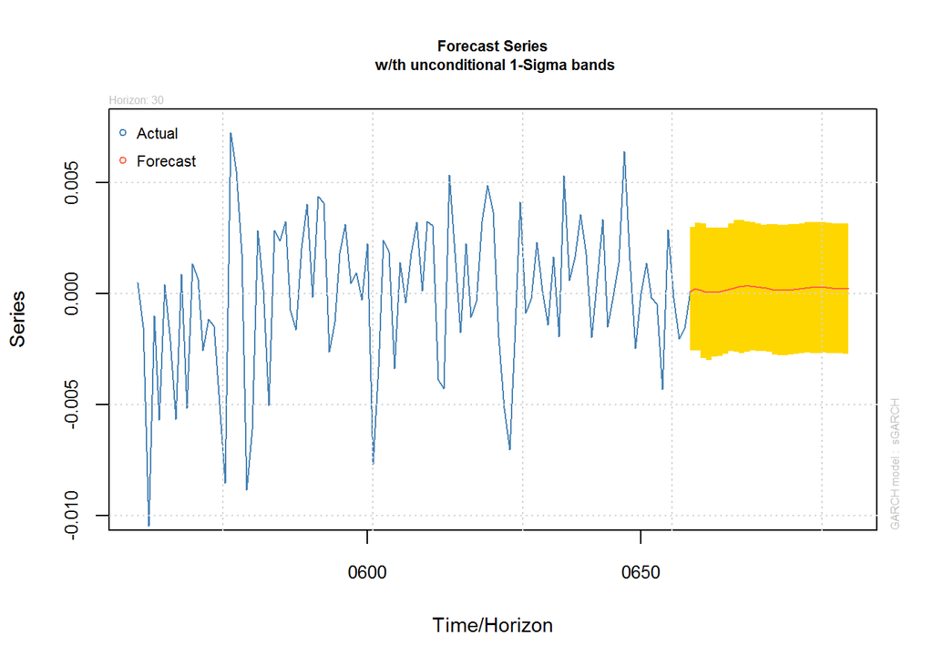

```r
forc<- ugarchforecast(fitORspec = garchFitt, data = kurs$`Kurs Jual`, n.ahead = 30, n.roll = 0)
plot(forc, which= 1)
```

```r
pt_1 <- kurs$`Kurs Jual`[650] #nilai akhir data latih
hasil.forc.Diff <- forc@forecast$seriesFor[,1]
hasil <- diffinv(hasil.forc.Diff, differences = 1) + pt_1

# Pastikan panjang kedua vektor sama
panjang_minimal <- min(length(kurs_ts), length(hasil))

# Buat data frame perbandingan dengan panjang minimal
perbandingan <- data.frame("Aktual" = kurs_ts[1:panjang_minimal], "Ramalan" = hasil[1:panjang_minimal])
head(perbandingan, 10)
```

```
##      Aktual  Ramalan
## 1  13972.52 15384.54
## 2  14014.73 15384.54
## 3  13995.63 15384.54
## 4  14007.69 15384.54
## 5  14128.29 15384.54
## 6  14225.78 15384.54
## 7  14302.16 15384.54
## 8  14179.55 15384.54
## 9  14189.60 15384.54
## 10 14138.34 15384.54
```